# Statistical Analysis of Lana’s dataset

v8 - 2020-11-02

# Install

To download all needed packages, execute renv::restore() the first time:

# General notes.

## Assumptions

We produce the residual plots. From top left to bottom right:

- Plot 1: The average error shoud be 0 (within random resampled lines). Then there is no systematic error.
- Plot 2: Redsiduals must be normally distributed, i.e. the points should lie on the diagonal line
- Plot 3: There should be homoscedasticity, i.e. the line should be straight.
- Plot 4: There should not be influenctial cases. outside the red dotted lines.

If all statistical assumptions are fulfilled, the generalisation is possible and estimation with MLR are robust. If not, google solutions.

# Data

## Data view

Let’s have a look at the original data. We remove several variables that, from a theortical consideration, are not relevant (and would sometimes cause collinearity). We also transform some values to a standard % format.

```r
#summary(combined_analysis)

combined_analysis_transformed <- combined_analysis #%>%
  #mutate(
    #pre_potential_EI = pre_potential_EI / 100)

summary(combined_analysis_transformed)
```

```
##  country_code         Country          mean_progress_NREAP
##  Length:28          Length:28          Min.   :-0.39873
##  Class :character   Class :character   1st Qu.:-0.02436
##  Mode  :character   Mode  :character   Median : 0.08404
##                                        Mean   : 0.08329
##                                        3rd Qu.: 0.17828
##                                        Max.   : 0.49853
##                                        NA's   :1
##  renewed_mean_progress_linear_trajectory prioritization_scale
##  Min.   :-0.241566                       Min.   :0.00000
##  1st Qu.:-0.084135                       1st Qu.:0.05383
##  Median : 0.010059                       Median :0.11941
##  Mean   :-0.009362                       Mean   :0.16830
##  3rd Qu.: 0.047878                       3rd Qu.:0.21691
##  Max.   : 0.211580                       Max.   :0.56169
##  NA's   :1
##  Prio_EE_REN        mean_GDP_growth       PPS_2015      subsidies_REN
##  Length:28          Min.   :-0.02400   Min.   : 48.00   Min.   :0.03851
##  Class :character   1st Qu.: 0.01319   1st Qu.: 73.75   1st Qu.:0.16328
##  Mode  :character   Median : 0.02006   Median : 89.50   Median :0.40487
##                     Mean   : 0.02142   Mean   :101.14   Mean   :0.42378
##                     3rd Qu.: 0.03050   3rd Qu.:122.00   3rd Qu.:0.57221
##                     Max.   : 0.06389   Max.   :272.00   Max.   :1.01266
##
##  subsidies_savings     Jobs_EE            Jobs_REN         EE_policies
##  Min.   :0.000583   Min.   :0.000175   Min.   :0.000175   Min.   :  0.00
##  1st Qu.:0.027677   1st Qu.:0.005291   1st Qu.:0.002171   1st Qu.:  2.75
##  Median :0.052632   Median :0.008790   Median :0.004286   Median : 20.50
##  Mean   :0.107699   Mean   :0.010721   Mean   :0.005115   Mean   : 23.86
##  3rd Qu.:0.158954   3rd Qu.:0.011848   3rd Qu.:0.007412   3rd Qu.: 33.25
##  Max.   :0.414384   Max.   :0.035225   Max.   :0.012680   Max.   :111.00
##  NA's   :7          NA's   :2          NA's   :1
##   REN_policies   normalized_social_tech_potential mean_intensity_0510
##  Min.   : 2.00   Min.   :0.1389                   Min.   : 85.89
##  1st Qu.: 8.50   1st Qu.:0.6756                   1st Qu.:137.28
##  Median :16.50   Median :1.1149                   Median :161.62
##  Mean   :17.68   Mean   :1.5304                   Mean   :203.93
##  3rd Qu.:26.50   3rd Qu.:2.0617                   3rd Qu.:278.31
##  Max.   :42.00   Max.   :4.6738                   Max.   :538.43
##                  NA's   :1                        NA's   :1
```

[output cut: 17 more lines]

```
##  Min.   :0.1338           Min.   :0.0688        Min.   :0.1434
##  1st Qu.:0.1721           1st Qu.:0.1621        1st Qu.:0.1774
##  Median :0.2026           Median :0.1973        Median :0.2011
##  Mean   :0.2103           Mean   :0.1985        Mean   :0.2075
##  3rd Qu.:0.2411           3rd Qu.:0.2518        3rd Qu.:0.2304
##  Max.   :0.3925           Max.   :0.3092        Max.   :0.3156
##
##  absolute_progress_EE absolute_progress_REN
##  Min.   :-0.229783    Min.   :0.02823
##  1st Qu.:-0.008881    1st Qu.:0.05988
##  Median : 0.030040    Median :0.07538
##  Mean   : 0.026480    Mean   :0.08388
##  3rd Qu.: 0.062073    3rd Qu.:0.10261
##  Max.   : 0.241199    Max.   :0.18509
##  NA's   :1            NA's   :1
```

## Remove missing cases

First we need to remove missing cases.

```
## [1] "For EE data: Of 28 cases 18 are left due to missing data,"
```

```
## [1] "For REN data: Of 28 cases 18 are left due to missing data,"
```

| countries | in_sample |
| --- | --- |
| AT | In the finale sample |
| BE | In the finale sample |
| BG | Missing |
| CY | Missing |
| CZ | In the finale sample |
| DE | In the finale sample |
| DK | In the finale sample |
| EE | In the finale sample |
| ES | In the finale sample |
| FI | In the finale sample |
| FR | In the finale sample |
| GB | In the finale sample |
| GR | Missing |
| HR | In the finale sample |
| HU | Missing |
| IE | Missing |
| IT | In the finale sample |
| LT | Missing |
| LU | Missing |
| LV | In the finale sample |
| MT | Missing |
| NL | Missing |
| PL | In the finale sample |
| PT | In the finale sample |
| RO | In the finale sample |
| SE | In the finale sample |
| SI | In the finale sample |
| SK | Missing |

[figure not shown]

Some data is missing that we can’t use in MLR, but most is there.

## Marginal plots

Let’s have a look at the data using marginal plots. This helps to see if any (potential) predictores are skewed. If this is the case, log() transformation will be applied in the regression model, which is a standard procedure to improve the model.

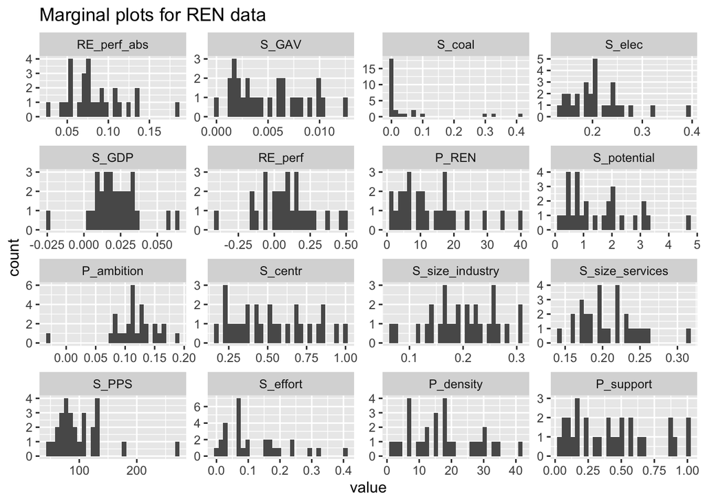

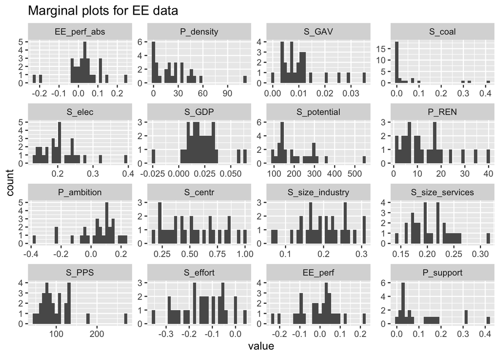

```r
Ren_both_effects[["wide_no_na"]] <- Ren_both_effects[["wide_no_na"]]
EE_both_effects[["wide_no_na"]] <- EE_both_effects[["wide_no_na"]]
```

## Correlations

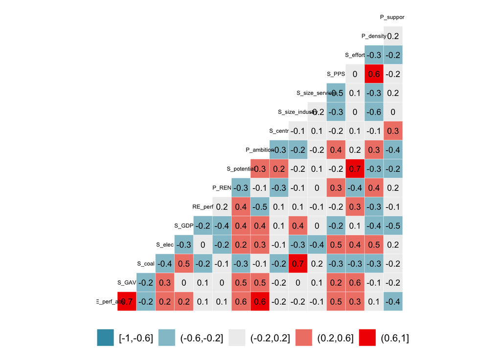

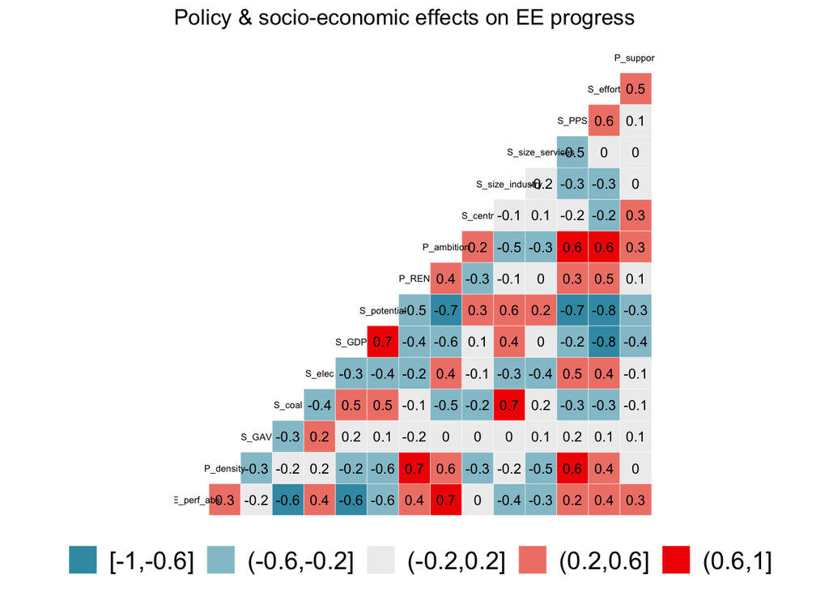

```r
GGally::ggcorr(EE_both_effects$wide_no_na %>% select(-EE_perf), nbreaks = 5, label = TRUE, size = 2,label_size = 3, legend.position = "bottom", legend.size = 15)  +
  ggtitle ("Policy & socio-economic effects on EE progress")
```

# Results

## 1) REN Performance relative (Renewable energy target performance)

### Full model

```r
full_models[["RE"]][["01_untransformed"]] <- lm(
  RE_perf ~
    P_density + P_ambition + P_REN +
    S_GAV + S_potential + S_effort + S_PPS + S_elec  + S_centr + S_GDP
  , data = Ren_both_effects[["wide_no_na"]])

summary(full_models$RE$`01_untransformed`)
```

```
##
## Call:
## lm(formula = RE_perf ~ P_density + P_ambition + P_REN + S_GAV +
##     S_potential + S_effort + S_PPS + S_elec + S_centr + S_GDP,
##     data = Ren_both_effects[["wide_no_na"]])
##
## Residuals:
##      Min       1Q   Median       3Q      Max
## -0.15868 -0.05654 -0.01415  0.05466  0.16680
##
## Coefficients:
##               Estimate Std. Error t value Pr(>|t|)
## (Intercept)   0.030608   0.331708   0.092   0.9291
## P_density    -0.007263   0.006618  -1.098   0.3087
## P_ambition   -2.291715   1.345338  -1.703   0.1323
## P_REN         0.007301   0.004732   1.543   0.1668
## S_GAV       -16.152868  18.955511  -0.852   0.4223
## S_potential   0.103181   0.043343   2.381   0.0488 *
## S_effort      0.132809   0.500767   0.265   0.7985
## S_PPS         0.002327   0.002067   1.126   0.2973
## S_elec        0.711154   1.433650   0.496   0.6351
## S_centr      -0.067107   0.180449  -0.372   0.7210
## S_GDP        -3.354240   6.563086  -0.511   0.6250
## ---
## Signif. codes:  0 '***' 0.001 '**' 0.01 '*' 0.05 '.' 0.1 ' ' 1
##
## Residual standard error: 0.1305 on 7 degrees of freedom
## Multiple R-squared:  0.7682, Adjusted R-squared:  0.4371
## F-statistic:  2.32 on 10 and 7 DF,  p-value: 0.1382
```

```r
faraway::vif(full_models$RE$`01_untransformed`)
```

```
##   P_density  P_ambition       P_REN       S_GAV S_potential    S_effort
##    6.055633    3.703444    2.934584    4.094397    3.132910    2.951558
##       S_PPS      S_elec     S_centr       S_GDP
##    2.716419    3.825246    1.642720    3.780995
```

### Stepwise selection

```r
full_models[["RE"]][["03_selected"]] <- select_model_and_print_analytics(
  full_models[["RE"]][["01_untransformed"]])
```

```
##
## Call:
## lm(formula = RE_perf ~ P_ambition + P_REN + S_potential, data = Ren_both_effects[["wide_no_na"]])
##
## Residuals:
##      Min       1Q   Median       3Q      Max
## -0.13201 -0.08797  0.01122  0.07650  0.16542
##
## Coefficients:
##              Estimate Std. Error t value Pr(>|t|)
## (Intercept)  0.165929   0.085342   1.944 0.072235 .
## P_ambition  -2.676432   0.608915  -4.395 0.000610 ***
## P_REN        0.005679   0.002455   2.313 0.036454 *
## S_potential  0.094028   0.022704   4.141 0.000998 ***
## ---
## Signif. codes:  0 '***' 0.001 '**' 0.01 '*' 0.05 '.' 0.1 ' ' 1
##
## Residual standard error: 0.1086 on 14 degrees of freedom
## Multiple R-squared:  0.6786, Adjusted R-squared:  0.6098
## F-statistic: 9.855 on 3 and 14 DF,  p-value: 0.0009426
##
##  P_ambition       P_REN S_potential
##    1.094336    1.139420    1.239973
```

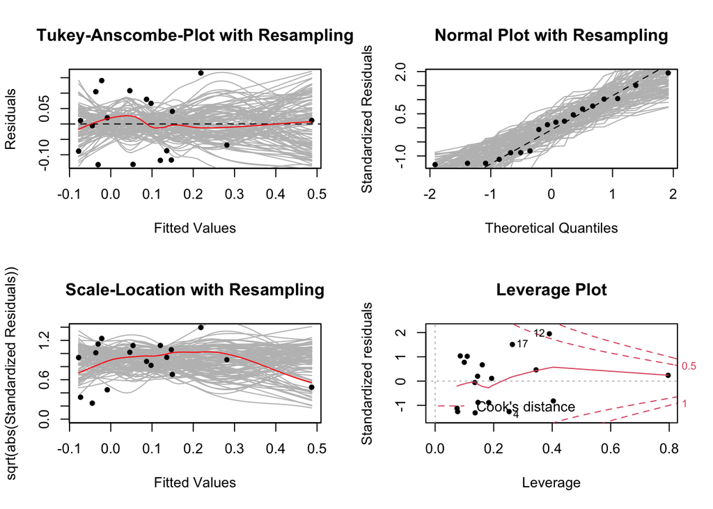

Assumptions look ok

### Custom model

```r
# Copy formula from full or stepwise model and customise
full_models[["RE"]][["04_custom"]] <- lm(
  RE_perf ~
    P_density + P_ambition + P_REN +
    S_GAV + S_potential + S_effort + S_PPS + S_elec  + S_centr + S_GDP,
  Ren_both_effects[["wide_no_na"]]
  )

custom_model_analytics(full_models[["RE"]][["04_custom"]])
```

```
##
## Call:
## lm(formula = RE_perf ~ P_density + P_ambition + P_REN + S_GAV +
##     S_potential + S_effort + S_PPS + S_elec + S_centr + S_GDP,
##     data = Ren_both_effects[["wide_no_na"]])
##
## Residuals:
##      Min       1Q   Median       3Q      Max
## -0.15868 -0.05654 -0.01415  0.05466  0.16680
##
## Coefficients:
##               Estimate Std. Error t value Pr(>|t|)
## (Intercept)   0.030608   0.331708   0.092   0.9291
## P_density    -0.007263   0.006618  -1.098   0.3087
## P_ambition   -2.291715   1.345338  -1.703   0.1323
## P_REN         0.007301   0.004732   1.543   0.1668
## S_GAV       -16.152868  18.955511  -0.852   0.4223
## S_potential   0.103181   0.043343   2.381   0.0488 *
## S_effort      0.132809   0.500767   0.265   0.7985
## S_PPS         0.002327   0.002067   1.126   0.2973
## S_elec        0.711154   1.433650   0.496   0.6351
## S_centr      -0.067107   0.180449  -0.372   0.7210
## S_GDP        -3.354240   6.563086  -0.511   0.6250
## ---
## Signif. codes:  0 '***' 0.001 '**' 0.01 '*' 0.05 '.' 0.1 ' ' 1
##
## Residual standard error: 0.1305 on 7 degrees of freedom
## Multiple R-squared:  0.7682, Adjusted R-squared:  0.4371
## F-statistic:  2.32 on 10 and 7 DF,  p-value: 0.1382
##
##   P_density  P_ambition       P_REN       S_GAV S_potential    S_effort
##    6.055633    3.703444    2.934584    4.094397    3.132910    2.951558
##       S_PPS      S_elec     S_centr       S_GDP
##    2.716419    3.825246    1.642720    3.780995
```

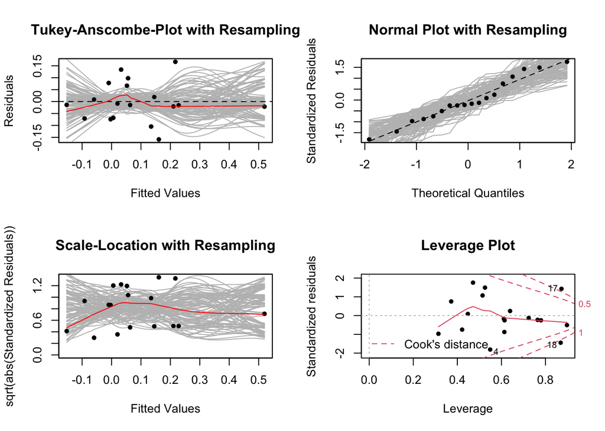

## 2) REN Performance absolute (system change)

### Full model

```r
full_models[["RE_perf_abs"]][["01_untransformed"]] <- lm(

  RE_perf_abs ~
    P_density + P_ambition + P_REN +
    S_GAV + S_potential + S_effort + S_PPS + S_elec  + S_centr + S_GDP,

    data = Ren_both_effects[["wide_no_na"]])

summary(full_models$RE$`01_untransformed`)
```

```
##
## Call:
## lm(formula = RE_perf ~ P_density + P_ambition + P_REN + S_GAV +
##     S_potential + S_effort + S_PPS + S_elec + S_centr + S_GDP,
##     data = Ren_both_effects[["wide_no_na"]])
##
## Residuals:
##      Min       1Q   Median       3Q      Max
## -0.15868 -0.05654 -0.01415  0.05466  0.16680
##
## Coefficients:
##               Estimate Std. Error t value Pr(>|t|)
## (Intercept)   0.030608   0.331708   0.092   0.9291
## P_density    -0.007263   0.006618  -1.098   0.3087
## P_ambition   -2.291715   1.345338  -1.703   0.1323
## P_REN         0.007301   0.004732   1.543   0.1668
## S_GAV       -16.152868  18.955511  -0.852   0.4223
## S_potential   0.103181   0.043343   2.381   0.0488 *
## S_effort      0.132809   0.500767   0.265   0.7985
## S_PPS         0.002327   0.002067   1.126   0.2973
## S_elec        0.711154   1.433650   0.496   0.6351
## S_centr      -0.067107   0.180449  -0.372   0.7210
## S_GDP        -3.354240   6.563086  -0.511   0.6250
## ---
## Signif. codes:  0 '***' 0.001 '**' 0.01 '*' 0.05 '.' 0.1 ' ' 1
##
## Residual standard error: 0.1305 on 7 degrees of freedom
## Multiple R-squared:  0.7682, Adjusted R-squared:  0.4371
## F-statistic:  2.32 on 10 and 7 DF,  p-value: 0.1382
```

```r
#faraway::vif(full_models$RE$`01_untransformed`)
```

### Stepwise

```r
full_models[["RE_perf_abs"]][["03_selected"]] <- select_model_and_print_analytics(
  full_models[["RE_perf_abs"]][["01_untransformed"]])
```

```
##
## Call:
## lm(formula = RE_perf_abs ~ P_density + P_ambition + P_REN + S_GAV +
##     S_potential + S_effort + S_PPS, data = Ren_both_effects[["wide_no_na"]])
##
## Residuals:
##        Min         1Q     Median         3Q        Max
## -0.0129917 -0.0065127 -0.0003858  0.0017875  0.0190396
##
## Coefficients:
##               Estimate Std. Error t value Pr(>|t|)
## (Intercept) -0.0369574  0.0129544  -2.853 0.017165 *
## P_density   -0.0011153  0.0003579  -3.116 0.010940 *
## P_ambition   0.1474353  0.0792916   1.859 0.092605 .
## P_REN        0.0005903  0.0003083   1.915 0.084557 .
## S_GAV        2.8381700  1.3187209   2.152 0.056852 .
## S_potential  0.0210112  0.0031059   6.765 4.95e-05 ***
## S_effort    -0.1384257  0.0404984  -3.418 0.006569 **
## S_PPS        0.0009626  0.0001639   5.874 0.000156 ***
## ---
## Signif. codes:  0 '***' 0.001 '**' 0.01 '*' 0.05 '.' 0.1 ' ' 1
##
## Residual standard error: 0.01105 on 10 degrees of freedom
## Multiple R-squared:  0.9464, Adjusted R-squared:  0.9089
## F-statistic: 25.22 on 7 and 10 DF,  p-value: 1.39e-05
##
##   P_density  P_ambition       P_REN       S_GAV S_potential    S_effort
##    2.469698    1.793961    1.736851    2.763373    2.243348    2.691971
##       S_PPS
##    2.381028
```

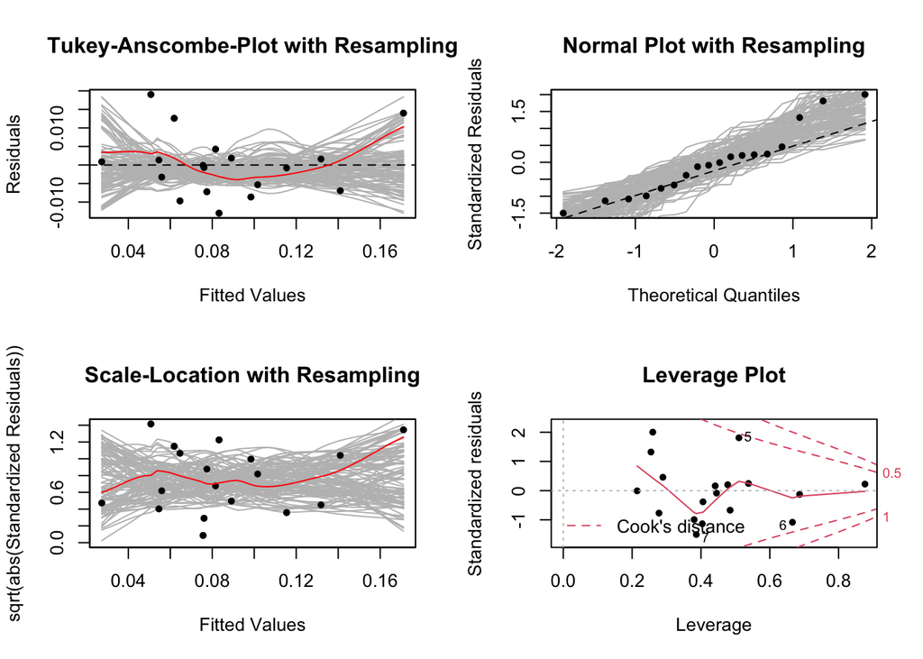

Looks ok.

### Custom

```r
# Copy formula from full or stepwise model and customise
full_models[["RE_perf_abs"]][["04_custom"]] <- lm(
  RE_perf_abs ~
    P_density + P_ambition + P_REN +
    S_GAV + S_potential + S_effort + S_PPS + S_elec  + S_centr + S_GDP,
  Ren_both_effects[["wide_no_na"]]
  )

custom_model_analytics(full_models[["RE_perf_abs"]][["04_custom"]])
```

```
##
## Call:
## lm(formula = RE_perf_abs ~ P_density + P_ambition + P_REN + S_GAV +
##     S_potential + S_effort + S_PPS + S_elec + S_centr + S_GDP,
##     data = Ren_both_effects[["wide_no_na"]])
##
## Residuals:
##        Min         1Q     Median         3Q        Max
## -0.0146676 -0.0045896 -0.0006008  0.0044347  0.0134934
##
## Coefficients:
##               Estimate Std. Error t value Pr(>|t|)
## (Intercept) -0.0121955  0.0310147  -0.393  0.70586
## P_density   -0.0008432  0.0006187  -1.363  0.21515
## P_ambition   0.1072980  0.1257891   0.853  0.42188
## P_REN        0.0003332  0.0004425   0.753  0.47596
## S_GAV        2.8812375  1.7723409   1.626  0.14805
## S_potential  0.0226264  0.0040526   5.583  0.00083 ***
## S_effort    -0.1292914  0.0468217  -2.761  0.02804 *
## S_PPS        0.0010065  0.0001933   5.208  0.00124 **
## S_elec      -0.1008299  0.1340463  -0.752  0.47646
## S_centr     -0.0172941  0.0168720  -1.025  0.33946
## S_GDP       -0.0755098  0.6136488  -0.123  0.90553
## ---
## Signif. codes:  0 '***' 0.001 '**' 0.01 '*' 0.05 '.' 0.1 ' ' 1
##
## Residual standard error: 0.0122 on 7 degrees of freedom
## Multiple R-squared:  0.9543, Adjusted R-squared:  0.8889
## F-statistic:  14.6 on 10 and 7 DF,  p-value: 0.0008911
##
##   P_density  P_ambition       P_REN       S_GAV S_potential    S_effort
##    6.055633    3.703444    2.934584    4.094397    3.132910    2.951558
##       S_PPS      S_elec     S_centr       S_GDP
##    2.716419    3.825246    1.642720    3.780995
```

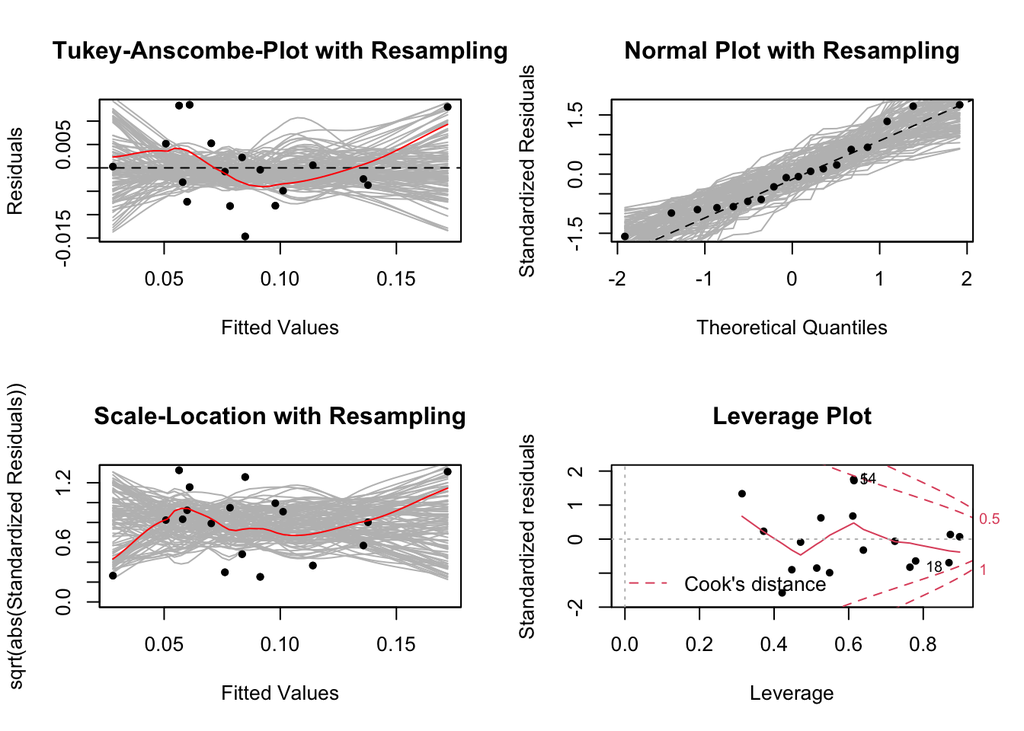

## 3) REN Ambition

Not used currently.

Assumptions of homoscedasticity are violated, and there is an influential outlier

## 4) EE Performance relative (system change)

```r
full_models[["EE"]][["01_untransformed"]] <- lm(
  EE_perf ~
    P_density + P_ambition + P_REN +
    S_GAV + S_potential + S_effort + S_PPS + S_elec + S_centr  + S_GDP
  , data = EE_both_effects[["wide_no_na"]])

#filter(!(country_code %in% c("RO","EE"))
#summary(full_models$EE$`01_untransformed`)
#faraway::vif(full_models$EE$`01_untransformed`)
```

```r
full_models[["EE"]][["03_selected"]] <- select_model_and_print_analytics(full_models[["EE"]][["01_untransformed"]])
```

```
##
## Call:
## lm(formula = EE_perf ~ P_density + P_REN + S_effort + S_PPS +
##     S_elec + S_centr + S_GDP, data = EE_both_effects[["wide_no_na"]])
##
## Residuals:
##       Min        1Q    Median        3Q       Max
## -0.043904 -0.015097 -0.002242  0.007380  0.078075
##
## Coefficients:
##               Estimate Std. Error t value Pr(>|t|)
## (Intercept)  0.0889955  0.0931567   0.955  0.36193
## P_density   -0.0014033  0.0005482  -2.560  0.02838 *
## P_REN        0.0026208  0.0013737   1.908  0.08551 .
## S_effort    -0.6960916  0.2118078  -3.286  0.00820 **
## S_PPS       -0.0009467  0.0005824  -1.625  0.13516
## S_elec       0.3624977  0.2818079   1.286  0.22731
## S_centr     -0.1600703  0.0418562  -3.824  0.00335 **
## S_GDP       -4.1751563  1.7218664  -2.425  0.03577 *
## ---
## Signif. codes:  0 '***' 0.001 '**' 0.01 '*' 0.05 '.' 0.1 ' ' 1
##
## Residual standard error: 0.03468 on 10 degrees of freedom
## Multiple R-squared:  0.8789, Adjusted R-squared:  0.7941
## F-statistic: 10.37 on 7 and 10 DF,  p-value: 0.0007033
##
## P_density     P_REN  S_effort     S_PPS    S_elec   S_centr     S_GDP
##  3.238847  3.500487  4.837402  3.053489  2.092337  1.251205  3.684181
```

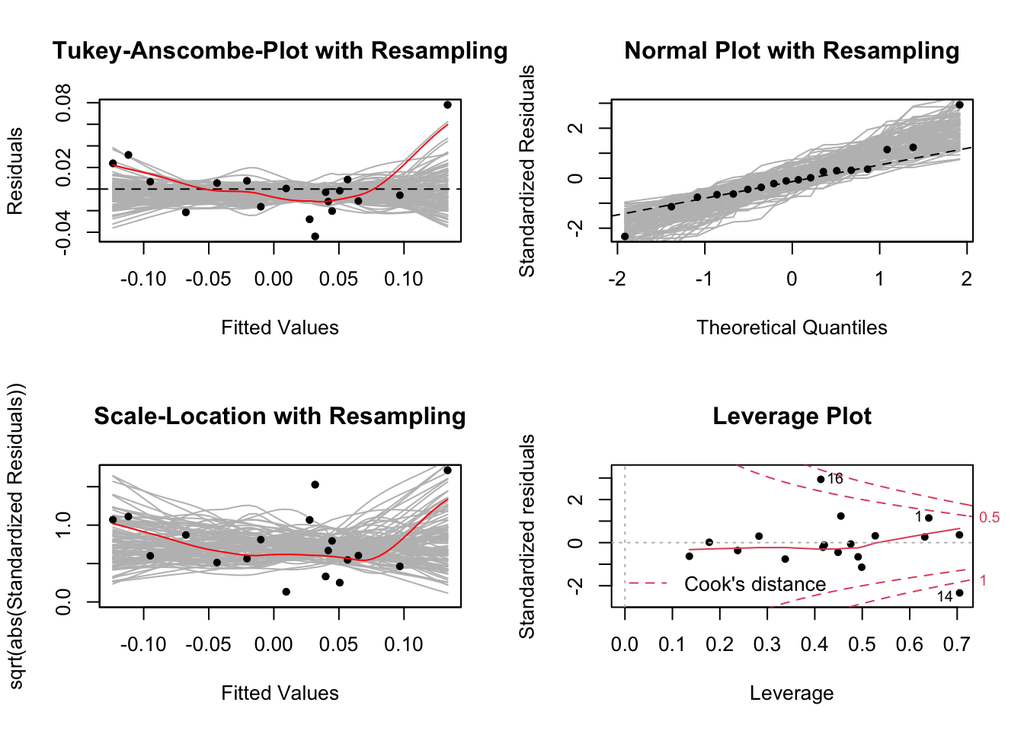

Assumptions critical, but iinside resamples area, so acceptable.

```r
check_outlier(c(16), "EE")
```

| country_code | EE_perf_abs | P_density | S_GAV | S_coal | S_elec | S_GDP | S_potential | P_REN | P_ambition | S_centr | S_size_industry | S_size_services | S_PPS | S_effort | EE_perf | P_support |
| --- | --- | --- | --- | --- | --- | --- | --- | --- | --- | --- | --- | --- | --- | --- | --- | --- |
| RO | 0.04349593 | 2 | 0.00735 | 0.09688386 | 0.1549454 | 0.03033333 | 307.2267 | 5.745 | -0.2317073 | 0.2770222 | 0.2858 | 0.1744 | 57 | -0.2888142 | 0.2115802 | 0.1479592 |

### Custom

(same results as in v4)

```r
# Copy formula from full or stepwise model and customise
full_models[["EE"]][["04_custom"]] <- lm(
  EE_perf ~ P_density + S_PPS +  S_effort + S_centr + S_GDP,
  EE_both_effects[["wide_no_na"]]
  )

custom_model_analytics(full_models[["EE"]][["04_custom"]])
```

```
##
## Call:
## lm(formula = EE_perf ~ P_density + S_PPS + S_effort + S_centr +
##     S_GDP, data = EE_both_effects[["wide_no_na"]])
##
## Residuals:
##       Min        1Q    Median        3Q       Max
## -0.064426 -0.021945  0.004041  0.016388  0.068485
##
## Coefficients:
##               Estimate Std. Error t value Pr(>|t|)
## (Intercept)  0.2240104  0.0582650   3.845  0.00233 **
## P_density   -0.0007728  0.0004412  -1.751  0.10535
## S_PPS       -0.0009987  0.0005714  -1.748  0.10601
## S_effort    -0.6419888  0.2243434  -2.862  0.01431 *
## S_centr     -0.1817039  0.0429140  -4.234  0.00116 **
## S_GDP       -5.1930158  1.7413849  -2.982  0.01144 *
## ---
## Signif. codes:  0 '***' 0.001 '**' 0.01 '*' 0.05 '.' 0.1 ' ' 1
##
## Residual standard error: 0.03706 on 12 degrees of freedom
## Multiple R-squared:  0.834,  Adjusted R-squared:  0.7649
## F-statistic: 12.06 on 5 and 12 DF,  p-value: 0.0002435
##
## P_density     S_PPS  S_effort   S_centr     S_GDP
##  1.837145  2.573540  4.752107  1.151694  3.299615
```

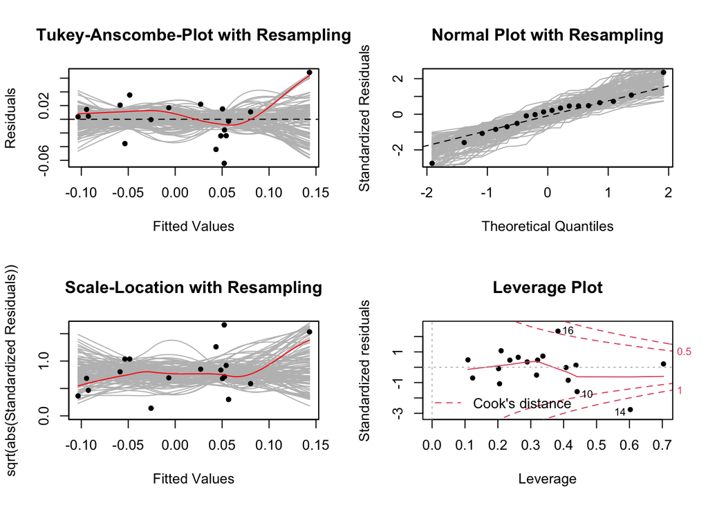

Redisdual not 0 for higher values but still in random resampling area.

## 5) EE Performance absolute

```r
full_models[["EE_perf_abs"]][["01_untransformed"]] <- lm(

  EE_perf_abs ~
    P_density + P_ambition + P_REN +
    S_GAV + S_potential + S_effort + S_PPS + S_elec  + S_centr + S_GDP,

    data = EE_both_effects[["wide_no_na"]])

#summary(full_models$EE_perf_abs$`01_untransformed`)
##faraway::vif(full_models$EE_perf_abs$`01_untransformed`)
```

```r
full_models[["EE_perf_abs"]][["03_selected"]] <- select_model_and_print_analytics(
  full_models[["EE_perf_abs"]][["01_untransformed"]])
```

```
##
## Call:
## lm(formula = EE_perf_abs ~ P_ambition + S_effort + S_centr +
##     S_GDP, data = EE_both_effects[["wide_no_na"]])
##
## Residuals:
##      Min       1Q   Median       3Q      Max
## -0.07308 -0.02460  0.01050  0.02123  0.10669
##
## Coefficients:
##             Estimate Std. Error t value Pr(>|t|)
## (Intercept)  0.08670    0.03641   2.381  0.03324 *
## P_ambition   0.55568    0.13811   4.023  0.00145 **
## S_effort    -0.77598    0.24526  -3.164  0.00747 **
## S_centr     -0.09845    0.06019  -1.636  0.12586
## S_GDP       -7.18607    1.97533  -3.638  0.00301 **
## ---
## Signif. codes:  0 '***' 0.001 '**' 0.01 '*' 0.05 '.' 0.1 ' ' 1
##
## Residual standard error: 0.04746 on 13 degrees of freedom
## Multiple R-squared:  0.761,  Adjusted R-squared:  0.6875
## F-statistic: 10.35 on 4 and 13 DF,  p-value: 0.0005418
##
## P_ambition   S_effort    S_centr      S_GDP
##   2.141006   3.462633   1.381101   2.588551
```

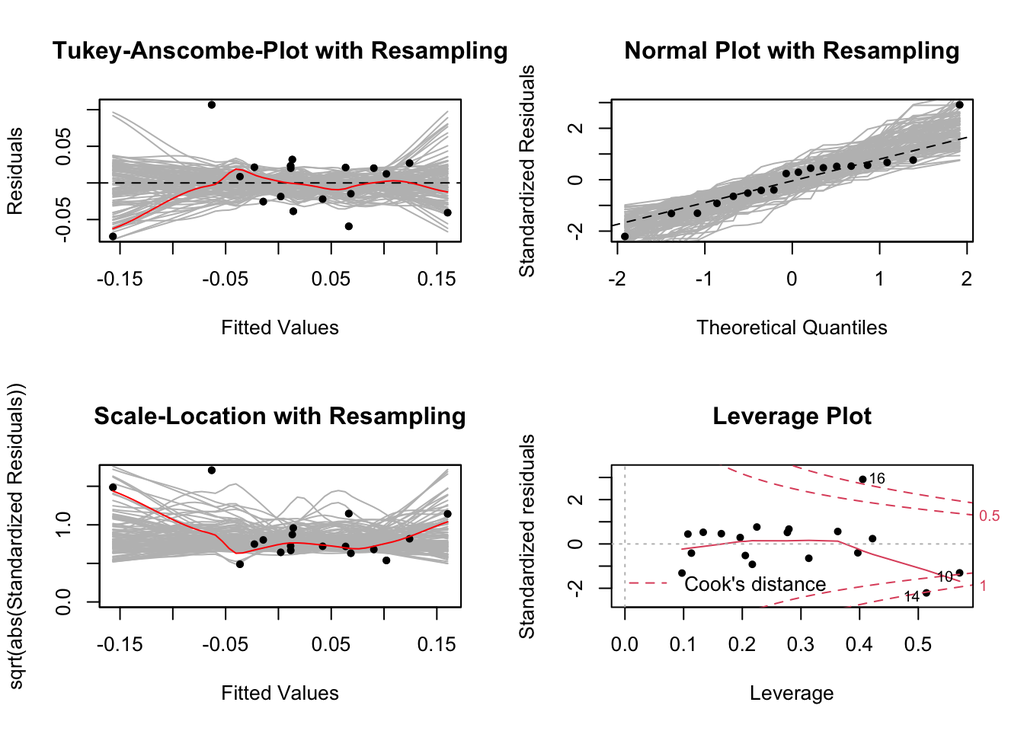

Assumptions may be slightly violated.

### Custom

```r
# Copy formula from full or stepwise model and customise
full_models[["EE_perf_abs"]][["04_custom"]] <- lm(
  EE_perf_abs ~
    P_ambition +
    S_effort + S_centr + S_GDP,
  EE_both_effects[["wide_no_na"]]
  )

custom_model_analytics(full_models[["EE_perf_abs"]][["04_custom"]])
```

```
##
## Call:
## lm(formula = EE_perf_abs ~ P_ambition + S_effort + S_centr +
##     S_GDP, data = EE_both_effects[["wide_no_na"]])
##
## Residuals:
##      Min       1Q   Median       3Q      Max
## -0.07308 -0.02460  0.01050  0.02123  0.10669
##
## Coefficients:
##             Estimate Std. Error t value Pr(>|t|)
## (Intercept)  0.08670    0.03641   2.381  0.03324 *
## P_ambition   0.55568    0.13811   4.023  0.00145 **
## S_effort    -0.77598    0.24526  -3.164  0.00747 **
## S_centr     -0.09845    0.06019  -1.636  0.12586
## S_GDP       -7.18607    1.97533  -3.638  0.00301 **
## ---
## Signif. codes:  0 '***' 0.001 '**' 0.01 '*' 0.05 '.' 0.1 ' ' 1
##
## Residual standard error: 0.04746 on 13 degrees of freedom
## Multiple R-squared:  0.761,  Adjusted R-squared:  0.6875
## F-statistic: 10.35 on 4 and 13 DF,  p-value: 0.0005418
##
## P_ambition   S_effort    S_centr      S_GDP
##   2.141006   3.462633   1.381101   2.588551
```

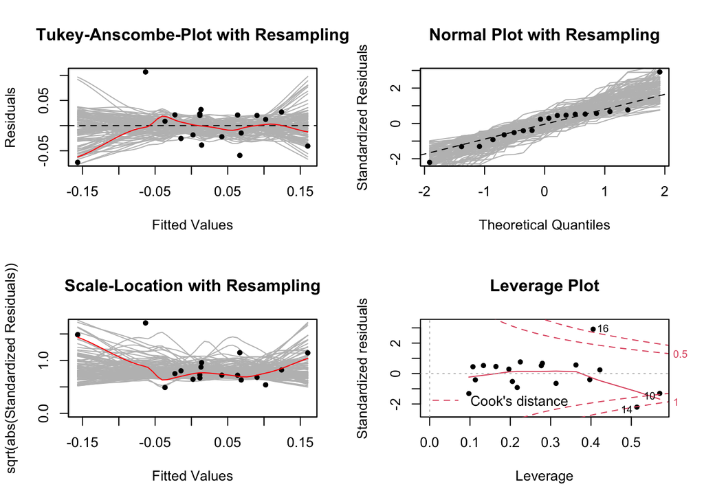

## 6) EE Ambition

Not used currently.

Assumptions slightly skewed, particularly 0-error assumptions, however withing resampled area. So acceptable.

# Result tables

```r
print_table_of_models <- function(variable, title = ""){

  tab_model(
    full_models[[variable]][["01_untransformed"]],
    full_models[[variable]][["03_selected"]],
    full_models[[variable]][["04_custom"]],

    dv.labels = c("Full model", "Selected model", "Custom"),
    pred.labels = variable_names,
    title = title,
    p.style = "stars",
    show.std = TRUE,
    p.threshold = c(0.1, 0.05, 0.01),
    digits = 3)

}
```

```r
print_table_of_models("RE", "Explaining REN Performance (relative)")
```

Explaining REN Performance (relative)

Full model

Selected model

Custom

Predictors

Estimates

std. Beta

CI

standardized CI

Estimates

std. Beta

CI

standardized CI

Estimates

std. Beta

CI

standardized CI

(Intercept)

0.031

-0.000

-0.754 – 0.815

-0.418 – 0.418

0.166 *

-0.000

-0.017 – 0.349

-0.316 – 0.316

0.031

-0.000

-0.754 – 0.815

-0.418 – 0.418

Policy density

-0.007

-0.491

-0.023 – 0.008

-1.550 – 0.567

-0.007

-0.491

-0.023 – 0.008

-1.550 – 0.567

Target Ambition  
(NEEAP/NREAP)

-2.292

-0.597

-5.473 – 0.890

-1.425 – 0.232

-2.676 ***

-0.697

-3.982 – -1.370

-1.037 – -0.357

-2.292

-0.597

-5.473 – 0.890

-1.425 – 0.232

Spending on renewable  
support schemes

0.007

0.481

-0.004 – 0.018

-0.256 – 1.218

0.006 **

0.374

0.000 – 0.011

0.027 – 0.721

0.007

0.481

-0.004 – 0.018

-0.256 – 1.218

Size of EE/REN sector

-16.153

-0.314

-60.976 – 28.670

-1.184 – 0.557

-16.153

-0.314

-60.976 – 28.670

-1.184 – 0.557

Technical potential

0.103 **

0.767

0.001 – 0.206

0.005 – 1.528

0.094 ***

0.699

0.045 – 0.143

0.337 – 1.061

0.103 **

0.767

0.001 – 0.206

0.005 – 1.528

Historical efforts

0.133

0.083

-1.051 – 1.317

-0.656 – 0.822

0.133

0.083

-1.051 – 1.317

-0.656 – 0.822

State affluence

0.002

0.338

-0.003 – 0.007

-0.372 – 1.047

0.002

0.338

-0.003 – 0.007

-0.372 – 1.047

Electricity available for  
final consumption

0.711

0.177

-2.679 – 4.101

-0.665 – 1.018

0.711

0.177

-2.679 – 4.101

-0.665 – 1.018

Centralization of the  
electricity market.

-0.067

-0.087

-0.494 – 0.360

-0.638 – 0.465

-0.067

-0.087

-0.494 – 0.360

-0.638 – 0.465

Economic growth

-3.354

-0.181

-18.873 – 12.165

-1.017 – 0.656

-3.354

-0.181

-18.873 – 12.165

-1.017 – 0.656

Observations

18

18

18

R<sup>2</sup> / R<sup>2</sup> adjusted

0.768 / 0.437

0.679 / 0.610

0.768 / 0.437

- p<0.1 ** p<0.05 *** p<0.01

```r
print_table_of_models("RE_perf_abs", "Explaining REN Performance (absolute)")
```

Explaining REN Performance (absolute)

Full model

Selected model

Custom

Predictors

Estimates

std. Beta

CI

standardized CI

Estimates

std. Beta

CI

standardized CI

Estimates

std. Beta

CI

standardized CI

(Intercept)

-0.012

-0.000

-0.086 – 0.061

-0.186 – 0.186

-0.037 **

-0.000

-0.066 – -0.008

-0.159 – 0.159

-0.012

-0.000

-0.086 – 0.061

-0.186 – 0.186

Policy density

-0.001

-0.271

-0.002 – 0.001

-0.742 – 0.199

-0.001 **

-0.359

-0.002 – -0.000

-0.615 – -0.102

-0.001

-0.271

-0.002 – 0.001

-0.742 – 0.199

Target Ambition  
(NEEAP/NREAP)

0.107

0.133

-0.190 – 0.405

-0.235 – 0.501

0.147 *

0.182

-0.029 – 0.324

-0.036 – 0.401

0.107

0.133

-0.190 – 0.405

-0.235 – 0.501

Spending on renewable  
support schemes

0.000

0.104

-0.001 – 0.001

-0.223 – 0.432

0.001 *

0.185

-0.000 – 0.001

-0.030 – 0.400

0.000

0.104

-0.001 – 0.001

-0.223 – 0.432

Size of EE/REN sector

2.881

0.266

-1.310 – 7.072

-0.121 – 0.653

2.838 *

0.262

-0.100 – 5.776

-0.009 – 0.533

2.881

0.266

-1.310 – 7.072

-0.121 – 0.653

Technical potential

0.023 ***

0.799

0.013 – 0.032

0.461 – 1.137

0.021 ***

0.742

0.014 – 0.028

0.498 – 0.986

0.023 ***

0.799

0.013 – 0.032

0.461 – 1.137

Historical efforts

-0.129 **

-0.384

-0.240 – -0.019

-0.712 – -0.055

-0.138 ***

-0.411

-0.229 – -0.048

-0.678 – -0.143

-0.129 **

-0.384

-0.240 – -0.019

-0.712 – -0.055

State affluence

0.001 ***

0.694

0.001 – 0.001

0.379 – 1.009

0.001 ***

0.664

0.001 – 0.001

0.412 – 0.915

0.001 ***

0.694

0.001 – 0.001

0.379 – 1.009

Electricity available for  
final consumption

-0.101

-0.119

-0.418 – 0.216

-0.493 – 0.255

-0.101

-0.119

-0.418 – 0.216

-0.493 – 0.255

Centralization of the  
electricity market.

-0.017

-0.106

-0.057 – 0.023

-0.351 – 0.139

-0.017

-0.106

-0.057 – 0.023

-0.351 – 0.139

Economic growth

-0.076

-0.019

-1.527 – 1.376

-0.391 – 0.352

-0.076

-0.019

-1.527 – 1.376

-0.391 – 0.352

Observations

18

18

18

R<sup>2</sup> / R<sup>2</sup> adjusted

0.954 / 0.889

0.946 / 0.909

0.954 / 0.889

- p<0.1 ** p<0.05 *** p<0.01

```r
#print_table_of_models("RE_amb", "Explaining REN Ambition")

print_table_of_models("EE", "Explaining EE Performance (relative)")
```

Explaining EE Performance (relative)

Full model

Selected model

Custom

Predictors

Estimates

std. Beta

CI

standardized CI

Estimates

std. Beta

CI

standardized CI

Estimates

std. Beta

CI

standardized CI

(Intercept)

0.070

-0.000

-0.303 – 0.443

-0.288 – 0.288

0.089

-0.000

-0.119 – 0.297

-0.238 – 0.238

0.224 ***

0.000

0.097 – 0.351

-0.249 – 0.249

Policy density

-0.001

-0.403

-0.003 – 0.001

-1.106 – 0.299

-0.001 **

-0.507

-0.003 – -0.000

-0.948 – -0.066

-0.001

-0.279

-0.002 – 0.000

-0.627 – 0.068

Target Ambition  
(NEEAP/NREAP)

-0.166

-0.264

-0.673 – 0.341

-1.074 – 0.545

Spending on renewable  
support schemes

0.003

0.423

-0.001 – 0.007

-0.195 – 1.042

0.003 *

0.393

-0.000 – 0.006

-0.066 – 0.852

Size of EE/REN sector

0.316

0.037

-3.191 – 3.822

-0.379 – 0.454

Technical potential

-0.000

-0.164

-0.001 – 0.001

-0.940 – 0.612

Historical efforts

-0.712 **

-0.814

-1.300 – -0.125

-1.486 – -0.143

-0.696 ***

-0.795

-1.168 – -0.224

-1.335 – -0.256

-0.642 **

-0.734

-1.131 – -0.153

-1.292 – -0.175

State affluence

-0.001

-0.337

-0.003 – 0.001

-1.066 – 0.392

-0.001

-0.313

-0.002 – 0.000

-0.741 – 0.116

-0.001

-0.330

-0.002 – 0.000

-0.741 – 0.081

Electricity available for  
final consumption

0.474

0.268

-0.419 – 1.368

-0.237 – 0.773

0.362

0.205

-0.265 – 0.990

-0.150 – 0.559

Centralization of the  
electricity market.

-0.110

-0.325

-0.294 – 0.073

-0.863 – 0.214

-0.160 ***

-0.471

-0.253 – -0.067

-0.745 – -0.196

-0.182 ***

-0.534

-0.275 – -0.088

-0.809 – -0.259

Economic growth

-4.305

-0.528

-10.304 – 1.695

-1.264 – 0.208

-4.175 **

-0.512

-8.012 – -0.339

-0.983 – -0.042

-5.193 **

-0.637

-8.987 – -1.399

-1.103 – -0.172

Observations

18

18

18

R<sup>2</sup> / R<sup>2</sup> adjusted

0.890 / 0.732

0.879 / 0.794

0.834 / 0.765

- p<0.1 ** p<0.05 *** p<0.01

```r
print_table_of_models("EE_perf_abs", "Explaining EE Performance (absolute)")
```

Explaining EE Performance (absolute)

Full model

Selected model

Custom

Predictors

Estimates

std. Beta

CI

standardized CI

Estimates

std. Beta

CI

standardized CI

Estimates

std. Beta

CI

standardized CI

(Intercept)

0.034

-0.000

-0.516 – 0.585

-0.383 – 0.383

0.087 **

0.000

0.008 – 0.165

-0.285 – 0.285

0.087 **

0.000

0.008 – 0.165

-0.285 – 0.285

Policy density

-0.001

-0.258

-0.004 – 0.002

-1.191 – 0.675

Target Ambition  
(NEEAP/NREAP)

0.593

0.852

-0.156 – 1.341

-0.224 – 1.927

0.556 ***

0.798

0.257 – 0.854

0.370 – 1.227

0.556 ***

0.798

0.257 – 0.854

0.370 – 1.227

Spending on renewable  
support schemes

0.002

0.289

-0.004 – 0.008

-0.534 – 1.111

Size of EE/REN sector

-0.136

-0.015

-5.310 – 5.038

-0.568 – 0.539

Technical potential

-0.000

-0.134

-0.001 – 0.001

-1.165 – 0.897

Historical efforts

-0.710 *

-0.731

-1.577 – 0.157

-1.623 – 0.162

-0.776 ***

-0.798

-1.306 – -0.246

-1.343 – -0.253

-0.776 ***

-0.798

-1.306 – -0.246

-1.343 – -0.253

State affluence

-0.001

-0.164

-0.004 – 0.003

-1.133 – 0.804

Electricity available for  
final consumption

0.406

0.207

-0.912 – 1.725

-0.464 – 0.877

Centralization of the  
electricity market.

-0.085

-0.225

-0.355 – 0.185

-0.940 – 0.491

-0.098

-0.261

-0.228 – 0.032

-0.605 – 0.084

-0.098

-0.261

-0.228 – 0.032

-0.605 – 0.084

Economic growth

-4.798

-0.530

-13.651 – 4.056

-1.508 – 0.448

-7.186 ***

-0.794

-11.454 – -2.919

-1.265 – -0.322

-7.186 ***

-0.794

-11.454 – -2.919

-1.265 – -0.322

Observations

18

18

18

R<sup>2</sup> / R<sup>2</sup> adjusted

0.805 / 0.527

0.761 / 0.687

0.761 / 0.687

- p<0.1 ** p<0.05 *** p<0.01

```r
#print_table_of_models("EE_amb", "Explaining EE Ambition")
```